# Introduction to Multivariate Regression

When a regression is performed in one variable, such as lm(child ~ parent, galton), it can yeilds two coefficients, a slope and an intercept. The intercept is really the coefficient of a special regressor which has the same value, 1, at every sample.

```r
data(galton)
n <- length(galton$child)

# create a regressor for the intercept. It needs to have the same number os samples as the data
ones <- rep(1, nrow(galton))

# regression
# exclude the default regressor and add the 'ones' above
lm(child ~ ones + parent - 1, galton)
```

```
Call:
lm(formula = child ~ ones + parent - 1, data = galton)

Coefficients:
   ones   parent
23.9415   0.6463
```

```r
# intercept have the same value
lm(child ~ parent, galton)
```

```
Call:
lm(formula = child ~ parent, data = galton)

Coefficients:
(Intercept)       parent
    23.9415       0.6463
```

The regression line given by `lm(child ~ parent, galton)` goes through the point `x=mean(parent)`, `y=mean(child)`.

If the mean is subtracted from each variable, the regression line goes through the origin, x=0, y=0, hence its intercept is zero.

Thus, by subtracting the means, the constant is eliminated, leaving just one regressor, parent. The coefficient of the remaining regressor is the slope.

Subtracting the means to eliminate the intercept is called **Gaussian Elimination**. The general technique is to pick one regressor and to replace all other variables by the residuals of their regressions against that one.

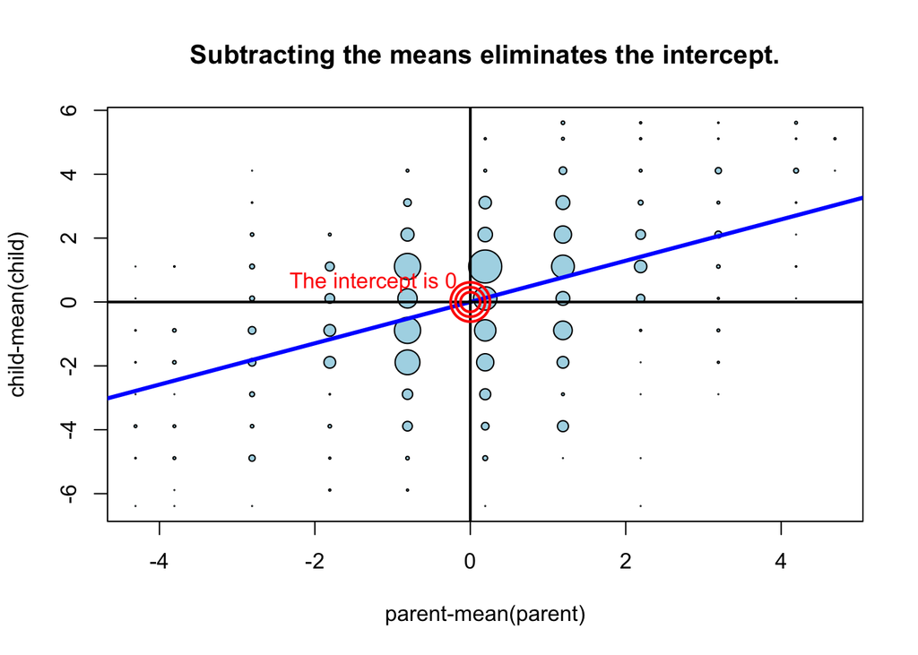

The mean of a variable is the coefficient of its regression against the constant, 1. Thus, subtracting the mean is equivalent to replacing a variable by the residual of its regression against 1. The expression `lm(child ~ 1, galton)` regresses child against the constant, 1.

```r
# compare the intercept and the mean height of child
lm(child ~1, galton)
```

```
Call:
lm(formula = child ~ 1, data = galton)

Coefficients:
(Intercept)
      68.09
```

```r
mean(galton$child)
```

```
[1] 68.08847
```

**The mean of a variable is equal to its regression against the constant, 1.**

```r
data(trees)
#View(trees)
str(trees)
```

```
'data.frame':   31 obs. of  3 variables:
 $ Girth : num  8.3 8.6 8.8 10.5 10.7 10.8 11 11 11.1 11.2 ...
 $ Height: num  70 65 63 72 81 83 66 75 80 75 ...
 $ Volume: num  10.3 10.3 10.2 16.4 18.8 19.7 15.6 18.2 22.6 19.9 ...
```

```r
source('elimination.R')

# pick one predictor and replace all other variables by the residuals of their regressions against that one.
# function regressOneOnOne in elimination.R

# fit model on all 3 regressors
trees$Constant <- rep(1, nrow(trees))
fit <- lm(Volume ~ Girth + Height + Constant - 1, trees)

# eliminate Girth from the data set
trees2 <- eliminate("Girth", trees)
head(trees2) # note the constant 1 has been replace by its residual when regressed against Girth
```

```
    Height     Volume  Constant
1 24.38809  -9.793826 0.4057735
2 17.73947 -10.520109 0.3842954
3 14.64038 -11.104298 0.3699767
4 14.29818  -9.019900 0.2482677
5 22.19910  -7.104089 0.2339490
6 23.64956  -6.446183 0.2267896
```

```r
# create a model using the reduced data set
fit2 <- lm(Volume ~ Height + Constant -1, trees2)

# print the coefficients of fit and fit2 for comparison
lapply(list(fit, fit2), coef)
```

```
[[1]]
      Girth      Height    Constant
  4.7081605   0.3392512 -57.9876589

[[2]]
     Height    Constant
  0.3392512 -57.9876589
```